# CLV Measurement Tutorial

## Number of Clusters

The first step in clustering is determining the optimal number of clusters for a given dataset. There are multiple methods that can be used to determine the optimal segments of a given dataset. This Wikipedia article has a review of some of them.

The elbow method is one of the most popular methods for finding the optimal number of clusters, that look at the percentage of variance, explained as a function of the number of clusters. It can be computed using the following function and then plotted for our dataset.

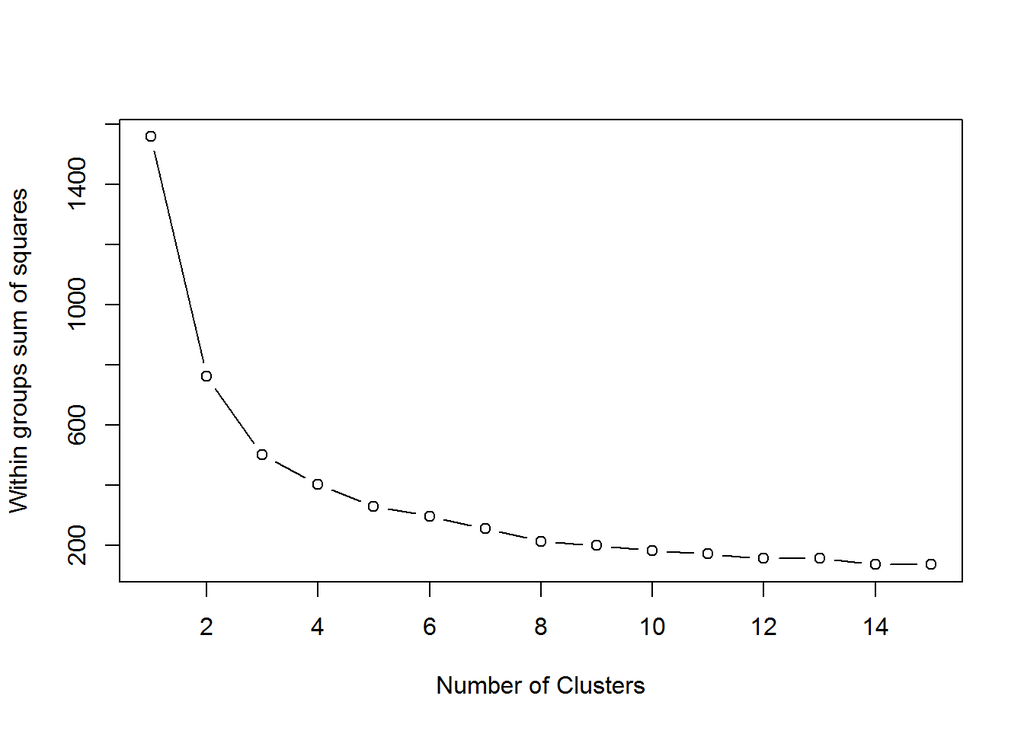

```r
wss <- (nrow(dfNorm)-1)*sum(apply(dfNorm,2,var))
for (i in 2:15) wss[i] <- sum(kmeans(dfNorm,centers=i)$withinss)
plot(1:15, wss, type="b", xlab="Number of Clusters", ylab="Within groups sum of squares")
```

After finding the optimal number of clusters, we use the k-means method the cluster our dataset:

```r
mydataCluster <- kmeans(dfNorm, 5, nstart = 20)
mydataCluster$cluster <- as.factor(mydataCluster$cluster)
```

## Visualize the clusters

Visualising the cluster provides more interpretability for a business. We can plot the results by selecting two of the variables as follows:

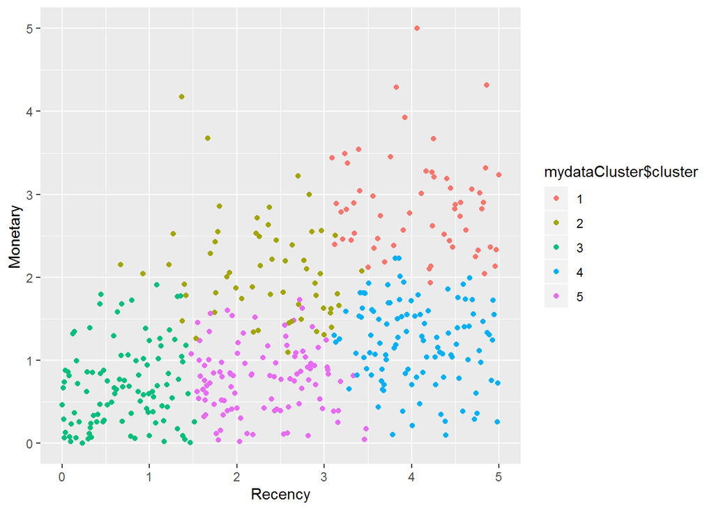

```r
library (ggplot2)
ggplot(dfNorm, aes(Recency, Monetary, color = mydataCluster$cluster)) + geom_point()
```

In order to visualise more than two variables, we can use various techniques. We believe the best approach is producing a matrix of scatterplots using the pairs function in R.

[figure not shown]

## Step 4: Generate rules

This step is extremely valuable and the rules provided can play an important role in our strategies. However this step is not necessary, and if you are merely interested in calculating the lifetime value of customers, this step can be skipped and you can go to step 5.

In order to provide more insights, we add a column that contains the number of clusters in our dataset.

```r
out <- cbind(dfNorm, clusterNum = mydataCluster$cluster)
```

We also added more variables to our dataset such as sociodemographic data (e.g. age, gender, etc.) and also online behaviour data such as (time on site, number of events and so on).

After adding variables and labelling the number of clusters to each customer, we want to mine some rules in our dataset to see the relationship between the selected variables, with the cluster of customers. Some techniques such as C.50 can be used for producing decision trees and rules.

In this article, we use association rule mining and Apriori algorithm to mine rules in our dataset. The following three terms help you to have a better understanding of association rule mining:

- Support= The indication of how frequently a variable appears in a dataset.
- Confidence = The indication of how often the rule has been found to be true
- Lift = The performance of a rule. A higher lift means a stronger rule.

Applying this model to our dataset resulted in the following rules:

- Gender = female, age = 20-30, time on site > 50 then class = 5
- Gender = male, age >40 and time on site = 300-500, then class =5

We can generate more rules by changing the support, confidence level, and also the variables in the appearance list.

Step 5: Calculate the net present value per cluster Lastly, we measure the lifetime value of each cluster. A basic formula is used for Lifetime value in this article as follows:

$LTV = CM_i (\frac {R}{1+d-R}) - AC_i$

Where

- CM= customers’ margin for each cluster
- R = retention rate of customers for each cluster
- d = discount rate
- AC= customer acquisition cost for each cluster

We measure the lifetime value for each cluster separately.

- CE = Number of customers at the end of the period for each cluster
- CN = Number of customers acquired during the period for each cluster
- CS = Number of customers at the start of the period for each cluster

Some parts of this article are taken from the article that I wtote on [Internetrix blog](https://www.internetrix.com.au/blog/blog-a-step-by-step-guide-to-calculate-your-customers-lifetime-value-using-clustering-2/)